# Data analysis and visualization using R

november 2015

## Contents

- distributions and their functions
- sampling from a distribution
- sampling from your own data
- statistical tests

## Distribution functions

## Distribution associated functions

- R provides related functions for several distributions that can be used for
  - sampling: **r**xxxx
  - Probability Density Function (PDF): **d**xxxx
  - Cumulative Distribution Function (CDF): **p**xxxx
  - Quantile Function (inverse of `pxxxx`): **q**xxxx

## `rnorm()`

- Random numbers from a normal distribution with parameters:
  - `n` number of observations
  - `mean` the mean of the distribution
  - `sd` the standard deviation of the distribution

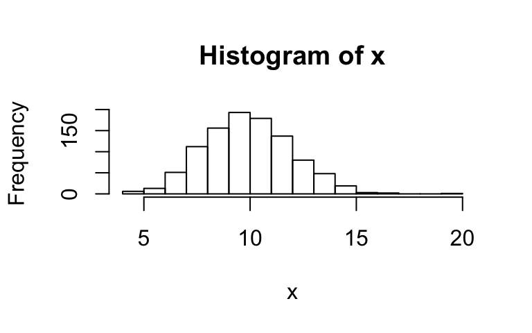

```r
x <- rnorm(n=1000, mean=10, sd=2)
hist(x, breaks=20)
```

## `dnorm()`

`dnorm(x, mean, sd)` gives the density (height) of x on the normal ditribution with the given mean and sd.

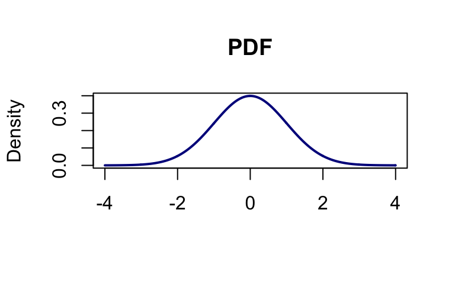

```r
xseq <- seq(-4, 4, 0.01)
densities <- dnorm(xseq, 0, 1)
plot(xseq, densities, col="darkblue", xlab="", ylab="Density",
     type="l", lwd=2, main="PDF")
```

## `pnorm()`

`pnorm(q, mean, sd)` gives the area under the standard normal curve to the left of q

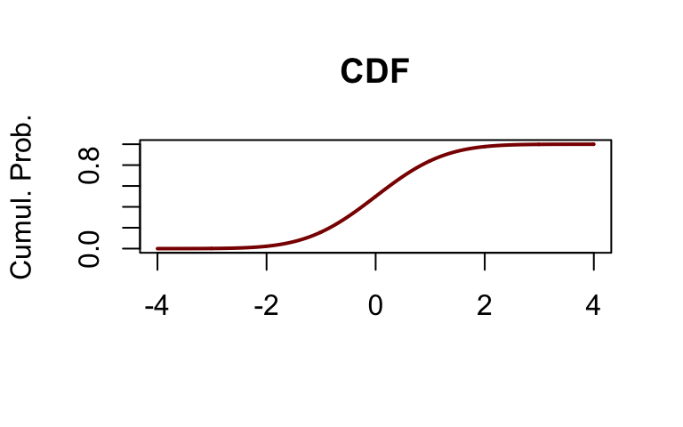

```r
xseq <- seq(-4, 4, 0.01)
cumulative <- pnorm(xseq, 0, 1)
plot(xseq, cumulative, col="darkred", xlab="", ylab="Cumul. Prob.",
     type="l", lwd=2, main="CDF")
```

## other distributions

Similar to the `xnorm()` functions, there are corresponding functions for

- the binomial distribution `xbinom()`
- the poisson distribution `xpois()`
- Chi square `chisq`
- and many others – see http://www.statmethods.net/advgraphs/probability.html

## Sampling from a set of values: `sample()`

- For some research aspects, shuffling the data (permutation) or taking random samples from a larger set is required.
- The `sample()` function can be used for both.

## permutations without replacement

```r
x <- 1:10
sample(x)
```

```
##  [1]  4  1  6  9  5  8  3  7  2 10
```

```r
sample(x)
```

```
##  [1]  8  2  4  9  1  7 10  6  3  5
```

## permutations with replacement

```r
sample(x, replace = T)
```

```
##  [1] 2 1 6 9 8 4 4 1 8 9
```

```r
sample(x, replace = T)
```

```
##  [1] 10  3  7  4  5  3  5  1  1  6
```

## sampling integers from range 1 to X

```
sample.int(1e3, 5, replace = F)
sample.int(2, 10, replace = T)
```

## sampling a fixed set

```r
sample(x, size = 2, replace = T)
```

```
## [1] 2 3
```

```r
sample(x, size = 2, replace = T)
```

```
## [1] 2 2
```

```r
sample(x, size = 2, replace = T)
```

```
## [1] 9 4
```

## sampling with probabilities

```r
sample(1:3, size = 10, replace = T, prob = c(0.25, 0.5, 0.25))
```

```
##  [1] 2 1 3 2 2 2 3 2 1 2
```

```r
sample(1:2, size = 10, replace = T, prob = c(0.2, 0.8))
```

```
##  [1] 2 2 2 2 2 1 2 2 2 1
```

## reproducible sampling using `set.seed()`

```r
set.seed(1234)
sample(x)
```

```
##  [1]  2  6  5  8  9  4  1  7 10  3
```

```r
set.seed(1234)
sample(x)
```

```
##  [1]  2  6  5  8  9  4  1  7 10  3
```

## statistic tests

## overview

| test | application | R function |
| --- | --- | --- |
| t-test | diff between 2 means | t.test( ) |
| F-test | diff between 2 variances | var.test( ) |
| 1-way ANOVA | diff between >=2 means | aov( ) |
| chi2-test | relation between 2 nominal vars | chisq.test( ) |
| z-test | standaard normaal verdeeld | z.test( ) * |

*[in package:TeachingDemos]

## t-test

The t-test can be used to determine if two sets of -normal distributed- data are significantly different from each other or from an expected distribution.

## Two sided

The dataset `InsectSprays` contains counts of insects in agricultural experimental units treated with different insecticides. Let's look at only two spray types, "A" and "B". The null hypothesis will state that there is no difference in effectiveness between the two sprays (the means of the tow samples is the same).

```r
spray.A <- InsectSprays[InsectSprays$spray == "A", "count"]
spray.B <- InsectSprays[InsectSprays$spray == "B", "count"]
spray.A; spray.B
```

```
##  [1] 10  7 20 14 14 12 10 23 17 20 14 13
```

```
##  [1] 11 17 21 11 16 14 17 17 19 21  7 13
```

```r
t.test(x = spray.A, y = spray.B)
```

```
##
##  Welch Two Sample t-test
##
## data:  spray.A and spray.B
## t = -0.45352, df = 21.784, p-value = 0.6547
## alternative hypothesis: true difference in means is not equal to 0
## 95 percent confidence interval:
##  -4.646182  2.979515
## sample estimates:
## mean of x mean of y
##  14.50000  15.33333
```

Thus, there is no evidence to support the alternative hypothsis.

## One sample, two sided

If we knew the expected insect counts (e.g. through historical data), we could have tested against an expected population average:

```r
t.test(x = spray.A, mu = 15)
```

```
##
##  One Sample t-test
##
## data:  spray.A
## t = -0.36701, df = 11, p-value = 0.7206
## alternative hypothesis: true mean is not equal to 15
## 95 percent confidence interval:
##  11.50144 17.49856
## sample estimates:
## mean of x
##      14.5
```

## One sample, one sided

If you are pretty certain the spray will NOT have a positive effect on insect counts, you can also perform a one sided test:

```r
t.test(x = spray.A, mu = 10, alternative = "greater")
```

```
##
##  One Sample t-test
##
## data:  spray.A
## t = 3.3031, df = 11, p-value = 0.00352
## alternative hypothesis: true mean is greater than 10
## 95 percent confidence interval:
##  12.05333      Inf
## sample estimates:
## mean of x
##      14.5
```

## GEO example

Tijd series, twee groepen met 4 tijdspunten. Informatie: http://www.ncbi.nlm.nih.gov/geo/query/acc.cgi?acc=GSE46051

```r
##look at the data
library(GEOquery)
View(GSE46051[[1]])
```

Load the expression data and create treatment groups

```r
data <- read.table("data/GSE46051_counts.txt",
                   sep = "\t",
                   head = T,
                   as.is = c(1, 2))
samples <- colnames(data[4:ncol(data)])
sample.fac <- factor(gsub("_R[0-9]", "", samples))
sample.fac
```

```
##  [1] DMSO_DAY1      DMSO_DAY1      DMSO_DAY1      Rotenone_DAY1
##  [5] Rotenone_DAY1  Rotenone_DAY1  DMSO_DAY5      DMSO_DAY5
##  [9] DMSO_DAY5      Rotenone_DAY5  Rotenone_DAY5  Rotenone_DAY5
## [13] DMSO_DAY10     DMSO_DAY10     DMSO_DAY10     Rotenone_DAY10
## [17] Rotenone_DAY10 Rotenone_DAY10 DMSO_DAY20     DMSO_DAY20
## [21] Rotenone_DAY20 Rotenone_DAY20
## 8 Levels: DMSO_DAY1 DMSO_DAY10 DMSO_DAY20 DMSO_DAY5 ... Rotenone_DAY5
```